# Chi Squared Test

```r
GSS2021 <- rio::import("../../Data/gss2021.sas7bdat")
library(tidyverse)
#glimpse(GSS2021)
library(mosaic)
library(ResourceSelection)
library(DT)
library(pander)
library(car)
library(haven)
```

```r
mychi1 <- filter(GSS2021, !is.na(MARITAL), !is.na(DEGREE)) |>
  mutate(MARITAL=as.factor(MARITAL),
         DEGREE=as.factor(DEGREE)) |>
  select(c(MARITAL, DEGREE))

mychi2 <- mychi1 |>
  mutate(DEGREE = case_when(
  DEGREE  == 0  ~ "Some High School",
  DEGREE  == 1 ~ "High School",
  DEGREE  == 2 ~ "Junior College",
  DEGREE  == 3  ~ "Bachelor",
  DEGREE  == 4 ~ "Graduate"
  ))

mychi22 <- mychi2%>%
  mutate(MARITAL=as.numeric(MARITAL))

mychi2 <- mychi2 |>
  mutate(MARITAL = case_when(
    MARITAL == 1 ~ "Married",
    MARITAL == 3 & 4 ~ "Divorced",
    MARITAL == 5 ~ "Never Married"
  ))
```

## Ho/Ha

Our questions for our data is: Is the level education and the marital status associated? The null hypothesis and alternative are as follows:

$$H_o:\text{Deegre and Marital Status are Independent}$$

$$H_a:\text{Deegre and Marital Status are Associated}$$
Level of significance for this analysis as follows:
$$\alpha = 0.05$$

## Numerical Summary

Let’s take a look at the table below, the counts of the Marital Status (rows) and the educations level or Degree (columns) are shows in this table summary. We can see that the counts of max education level reached are higher for Married people, it could be because the data might have more entries of married people. We can see a trend on that Divorces people have the least count for each degree type, and never married one ar in the middle. To determine if there is an association between Degree and Marital Status, we need to conduct an analysis that will be shown later as we go over other summaris before perfoming and analyzing the test results.

```r
mychi2table <- table(mychi2$MARITAL, mychi2$DEGREE)
pander(mychi2table)
```

Table continues below

|  | Bachelor | Graduate | High School | Junior College |
| --- | --- | --- | --- | --- |
| **Divorced** | 130 | 90 | 314 | 75 |
| **Married** | 557 | 477 | 695 | 172 |
| **Never Married** | 269 | 140 | 385 | 94 |

|  | Some High School |
| --- | --- |
| **Divorced** | 44 |
| **Married** | 87 |
| **Never Married** | 77 |

## Graphical Summary

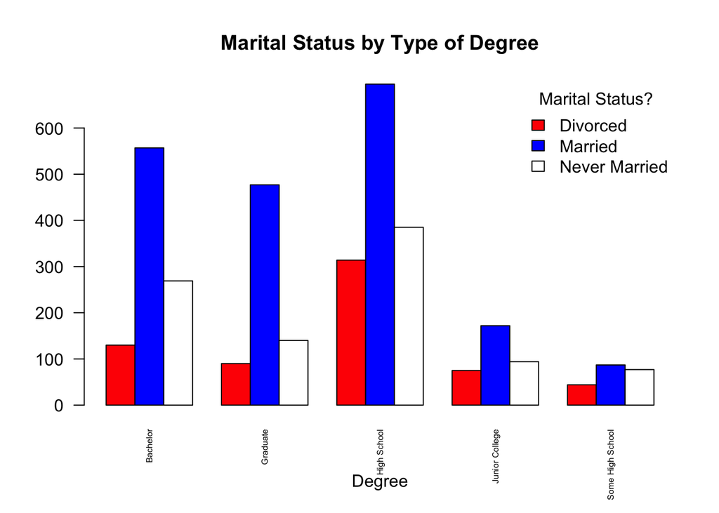

```r
barplot(mychi2table, beside=TRUE,
col=c("red","blue","white"),legend.text=TRUE,
args.legend = list(x="topright",bty="n",title="Marital Status?"),
xlab="Degree",main="Marital Status by Type of Degree",las=2,,cex.names=.5)
```

## Chi-Squared Model Analysis

We can either reject or fail to reject the null hypothesis by running a Chi-Square Test. That’s how we will find a conclusion for this analysis to see if the marital status and degree (maximum level of education) are independent or associated.

```r
mychisq = chisq.test(mychi2table)
pander(mychisq)
```

Pearson’s Chi-squared test: `mychi2table`

| Test statistic | df | P value |
| --- | --- | --- |
| 99.37 | 8 | 5.746e-18 * * * |

Our test results show a p-value of p = 5.746e-18, which is smaller than the level of significance used for this analysis α=0.05. Based on the results, we can reject the null hypothesis.

We will also take a look at the expected count to determine if the Chi-Square test requirement are met to perform the test.

## Check for the Requirements.

The expected count are all greater than 5, so the requirements are met for to perform a Chi-Square Test.

```r
pander(mychisq$expected)
```

Table continues below

|  | Bachelor | Graduate | High School | Junior College |
| --- | --- | --- | --- | --- |
| **Divorced** | 173.1 | 128 | 252.4 | 61.75 |
| **Married** | 527 | 389.8 | 768.5 | 188 |
| **Never Married** | 255.8 | 189.2 | 373 | 91.25 |

|  | Some High School |
| --- | --- |
| **Divorced** | 37.67 |
| **Married** | 114.7 |
| **Never Married** | 55.66 |

```r
mean(mychisq$expected)
```

```
## [1] 240.4
```

## Check for Residuals of Chi-squared Test

Let’s take a look at the residuals for this analysis. Here is where we can see how much our observed count differ from the expected counts if the null hypothesis were true.

```r
pander(mychisq$residuals)
```

Table continues below

|  | Bachelor | Graduate | High School | Junior College |
| --- | --- | --- | --- | --- |
| **Divorced** | -3.277 | -3.361 | 3.875 | 1.686 |
| **Married** | 1.305 | 4.418 | -2.652 | -1.167 |
| **Never Married** | 0.8231 | -3.577 | 0.6188 | 0.2874 |

|  | Some High School |
| --- | --- |
| **Divorced** | 1.032 |
| **Married** | -2.584 |
| **Never Married** | 2.86 |

## Conclusion/Future Studies

Based on the results that we obtain by performing the Chi-Square Test, we conclude that we reject the null hypothesis because the p-value of p = 5.746e-18 is lower the the significance level of 0.05. It means that the marital status and the degree or maximum education level are associated. Future studies can be conducted with more consistent data by having the same number of counts/entries by each category of marital status so we can conduct an analysis and compare the results to this test to see if there is any difference by having the same counts for marital status or not.